# Analysis of The World Happiness

Group 21-Ananth Padakannaya,Nivedita Patil,Li Wang,Wanqing Yang,Boyao Ma

2021/7/02

# Introduction

Happiness of an individual depends on multiple factors and the surrounding environment plays a key role in determining it. This survey on world happiness gives an insight into how happiness changes in our lives. Covid-19 has an adverse impact on our lives and it brings to attention the people’s subjective well-being in the world at the moment and the factors affecting it. “As the pandemic struck, there was a large and immediate decline in mental health in many countries worldwide”(Helliwell et al. 2021). Therefore, it seems necessary to give more importance to happiness and well-being, thereby achieving better social and economic development (Greyling, Rossouw, and Adhikari 2021). Our study mainly aims to serve two purposes. Firstly ,we aim to find and evaluate the influential factors of happiness. Secondly, we aim to trace the size and distribution of happiness globally. We adopt the multiple regression analysis based on the data from the Gallup World Poll. There are six variables to measure happiness scores of 149 countries or territories. After processing the data, we finally get three influential factors.

# Exploratory Data Analysis

At first, we choose seven variables with one outcome variable, Happy score and six explanatory variables. They are as follows: Logged GDP per capita, Social support, Healthy life expectancy, Freedom to make life choices, Generosity and Perceptions of corruption. The following is the interpretation of each of these variables in the data observed.

Happy score (score): respondents were asked to rate their possible lives from one to ten, with 1 being the worst and 10 being the best.

Logged GDP per capita (LoggedGDP): it denotes the logged GDP index from 149 countries.

Social support (Social): it denotes if the participants could find someone’s help when they are in trouble.

Healthy life expectancy (expectancy): it denotes the expected life expectancy.

Freedom to make life choices (Freedom): it denotes if the participants are satisfied with their freedom to choose what they do in life.

Generosity: it denotes if the participants are generous after asking if they have donated money to charity organizations.

Perceptions of corruption (corruption): it denotes if the participants are conscious of the corruption within the government and business.

We visualize the values as boxplots:

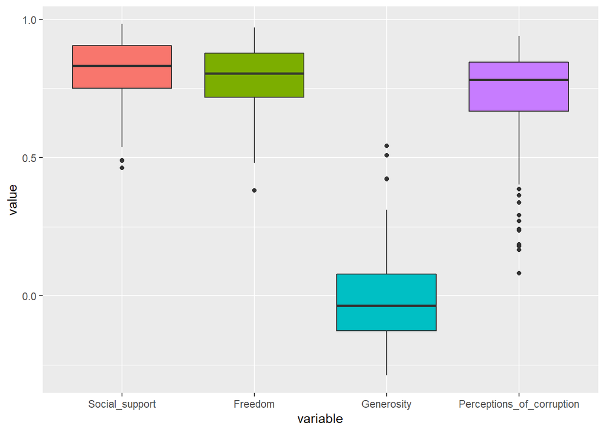

Boxplots of six variables.

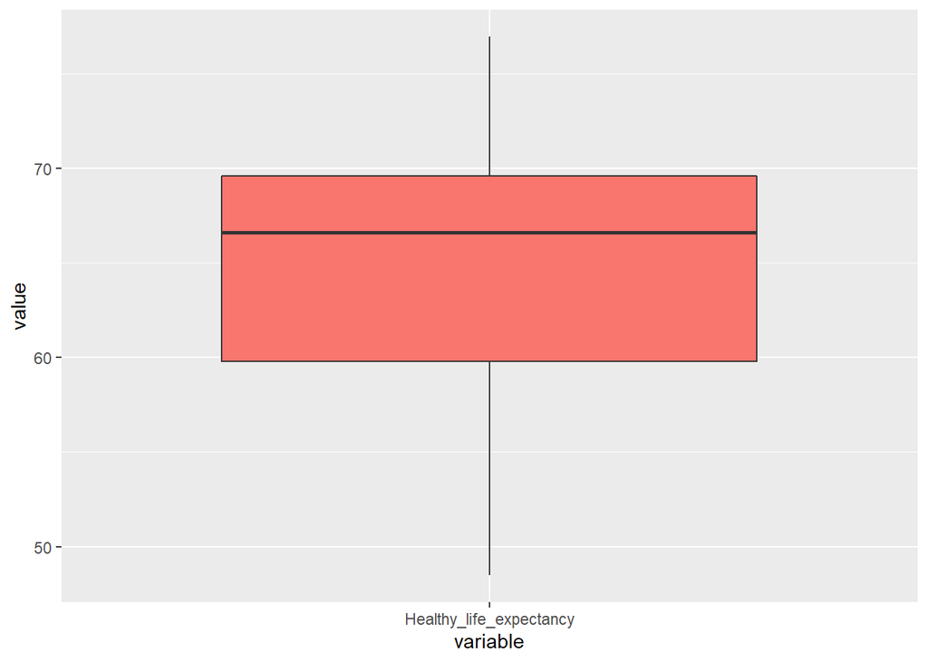

Boxplots of six variables.

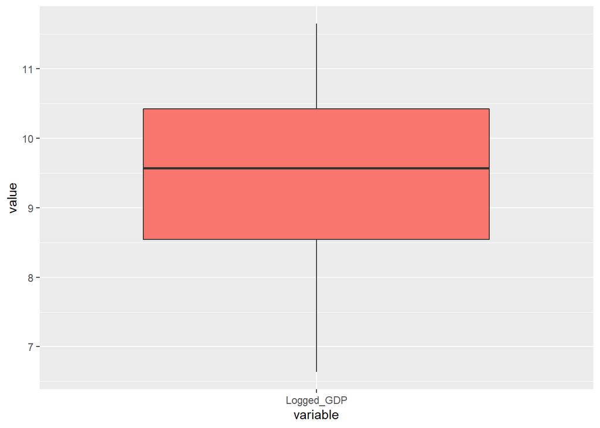

Boxplots of six variables.

Figure 1 shows the descriptive statistics of four variables - Social support, Freedom, Generosity and Perceptions of corruption. It is obvious that apart from Generosity, people in more than half of the countries grade more than 0.6 on Social support, Freedom and Perceptions of corruption although there are some outliers lower than 0.5. And figure 2 shows half of the population has a life span of 60 to 70 years. The figure 3 shows the median of Logged GDP is near 9.5.

Next we use table to illustrate the details of all seven variables.

Summary statistics for observations with chosen variables.

|  | score | LoggedGDP | Social | expectancy | Freedom | Generosity | corruption |
| --- | --- | --- | --- | --- | --- | --- | --- |
|  | Min. :2.523 | Min. : 6.635 | Min. :0.4630 | Min. :48.48 | Min. :0.3820 | Min. :-0.28800 | Min. :0.0820 |
|  | 1st Qu.:4.852 | 1st Qu.: 8.541 | 1st Qu.:0.7500 | 1st Qu.:59.80 | 1st Qu.:0.7180 | 1st Qu.:-0.12600 | 1st Qu.:0.6670 |
|  | Median :5.534 | Median : 9.569 | Median :0.8320 | Median :66.60 | Median :0.8040 | Median :-0.03600 | Median :0.7810 |
|  | Mean :5.533 | Mean : 9.432 | Mean :0.8147 | Mean :64.99 | Mean :0.7916 | Mean :-0.01513 | Mean :0.7274 |
|  | 3rd Qu.:6.255 | 3rd Qu.:10.421 | 3rd Qu.:0.9050 | 3rd Qu.:69.60 | 3rd Qu.:0.8770 | 3rd Qu.: 0.07900 | 3rd Qu.:0.8450 |
|  | Max. :7.842 | Max. :11.647 | Max. :0.9830 | Max. :76.95 | Max. :0.9700 | Max. : 0.54200 | Max. :0.9390 |

Table 1 describes some basic features of those variables. For example, the average happiness score is 5.533 and the median is 5.534. It demonstrates that people’s feelings of happiness or subjective well-beings are neither high nor low.

# Visualization of the data

We can visualize our data by producing histogram and radarplot, whereby taking note that we have several countries to compare, we shall plot the bars or lines using different colours for each country:

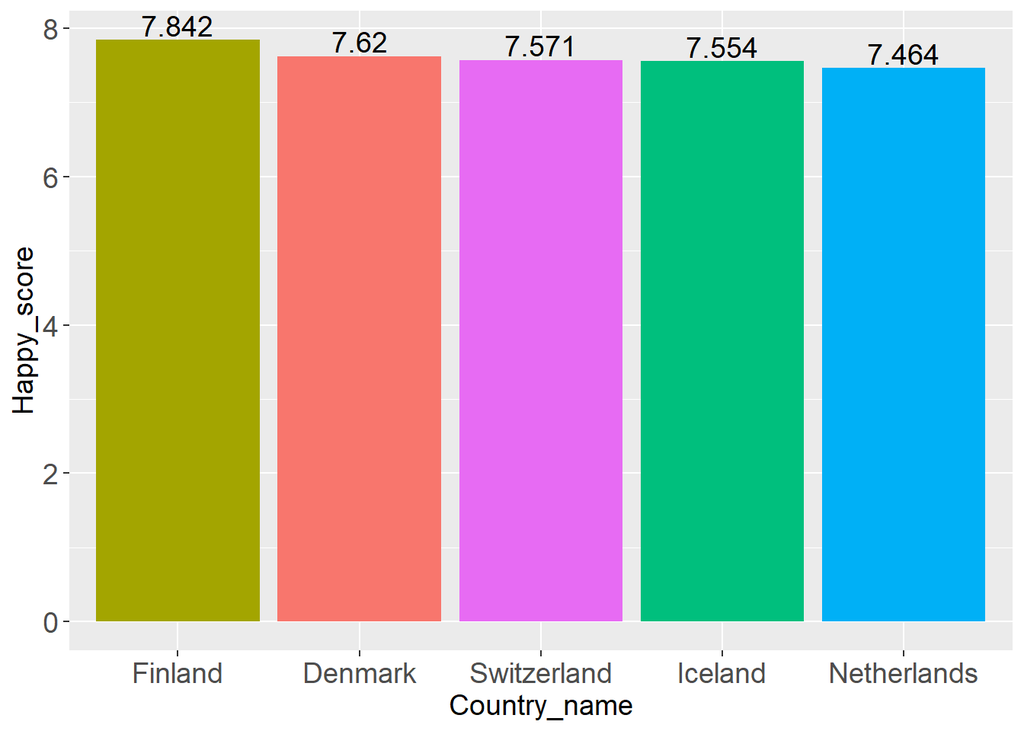

The 5 happiest countries.

Figure 4 shows the top 5 happiest countries. Finland gets the highest happy score with 7.842, followed by Denmark at 7.62. in addition, the differences between those five countries are small, less than 0.4, and all scores are greater than 7.4.

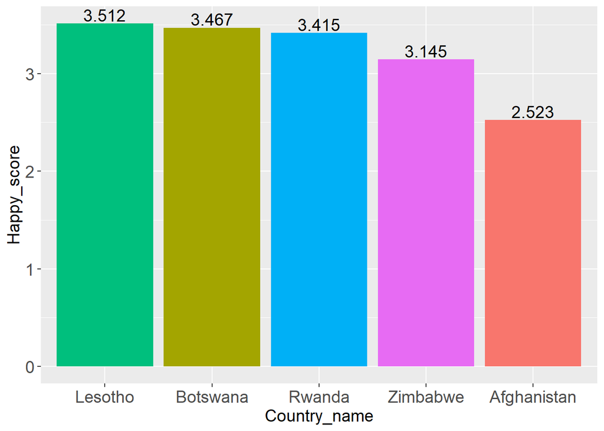

The 5 most unhappy countries.

Figure 5 shows the 5 most unhappy countries. Afghanistan takes the position as the most unhappy country with the score of 2.523. And the other four countries have similar scores lower than 3.6. Other than Afghanistan from South Asia, other four countries are in Africa.

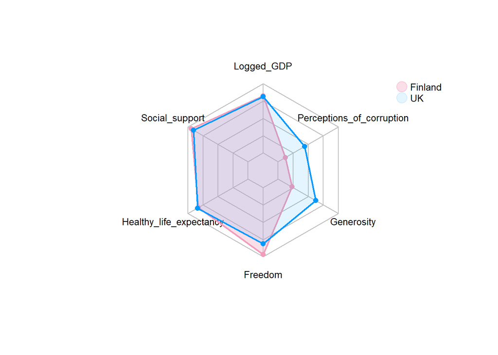

Comparisons between Finland and the UK from six indexes.

Figure 6 compares those six dimensions that Finland obtains with those that UK obtains. There are obvious differences between the perceptions of corruption and generosity, with the UK getting comparatively much higher values. Conversely, when referring to Freedom indicators, Finland has a slightly higher value. Besides, it owns similar grades among the other three aspects.

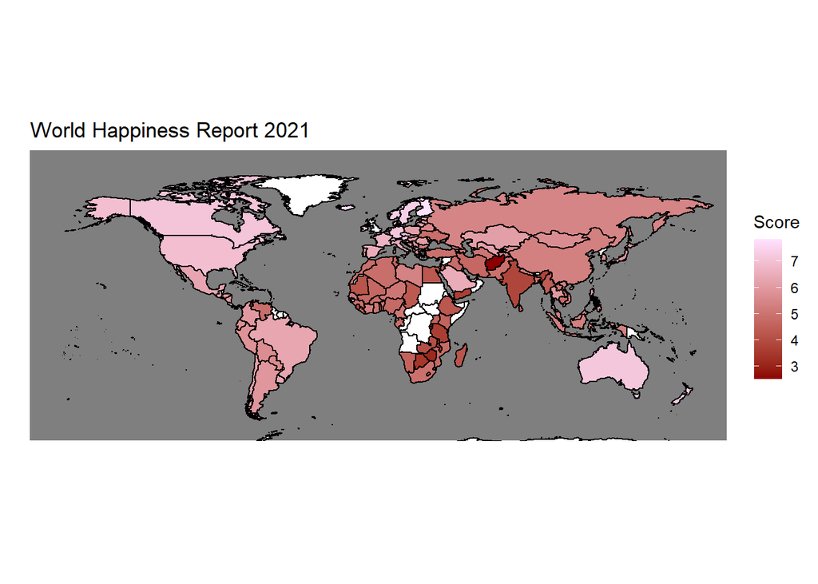

World happiness score map.

# Formal Data Analysis

To begin the analysis on the world happiness dataset, we need to check the correlation between the six explanatory variables to avoid the problem of multicollinearity.

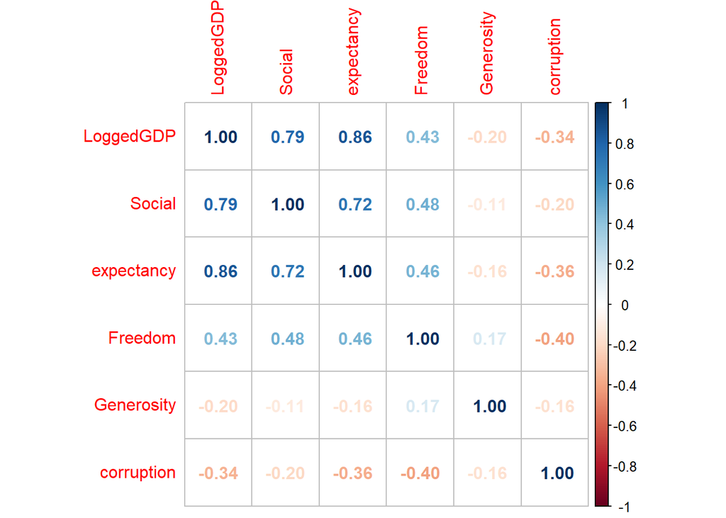

Correlation coefficient table.

From our correlation table we can see that the correlation between our Logged GDP and Healthy life expectancy is 0.859, which is a strong positive linear relationship. And the Logged GDP and Social support also have the high degree of collinearity. The correlation between this two variables is 0.785. So we remove Healthy life expectancy and Logged GDP. We then use the remaining four explanatory variables to perform stepwise regression, and observe whether the remaining variables need to be eliminated.

```
Start:  AIC=-141.88
score ~ Social + Freedom + Generosity + corruption

             Df Sum of Sq    RSS      AIC
- Generosity  1     0.091 53.856 -143.628
<none>                    53.765 -141.879
- corruption  1     6.078 59.843 -127.920
- Freedom     1     6.364 60.129 -127.210
- Social      1    43.953 97.718  -54.857

Step:  AIC=-143.63
score ~ Social + Freedom + corruption

             Df Sum of Sq     RSS      AIC
<none>                     53.856 -143.628
- corruption  1     5.988  59.844 -129.919
- Freedom     1     6.325  60.181 -129.082
- Social      1    47.398 101.254  -51.561
```

```
Call:
lm(formula = score ~ Social + Freedom + corruption, data = happiness)

Coefficients:
(Intercept)       Social      Freedom   corruption
     0.0779       5.6256       2.2271      -1.2254
```

According to the results of stepwise regression, we choose the model with the smallest AIC as the final model.Then,we fit the following linear model to the data.
$$\widehat{\mbox{score}}_{\mbox{i}} = \widehat{\alpha} +
{\widehat\beta}*{\mbox{Social}}_{\mbox{i}} +\widehat{\gamma}*{\mbox{Freedom}}_{\mbox{i}}+\widehat{\delta}*{\mbox{corruption}}_{\mbox{i}}$$

where

• the $\widehat{\mbox{score}}_{\mbox{i}}$: the happiness score of the $i\mbox{th}$ country.

• the $\widehat{\alpha}$: the intercept of the regression line.

• the $\widehat{\beta}$: the coefficient for the first explanatory variable ${\mbox{Social}}$.

• the $\widehat{\gamma}$: the coefficient for the second explanatory variable ${\mbox{Freedom}}$.

• the $\widehat{\delta}$: the coefficient for the second explanatory variable ${\mbox{corruption}}$.

When this model is fitted to the data, the following estimates of ${\alpha}$ (intercept) and ${\beta}$,${\gamma}$ and ${\delta}$ are returned:

Estimates of the parameters from the fitted linear regression model.

| term | estimate | std_error | statistic | p_value | lower_ci | upper_ci |
| --- | --- | --- | --- | --- | --- | --- |
| intercept | 0.078 | 0.559 | 0.139 | 0.889 | -1.028 | 1.184 |
| Social | 5.626 | 0.498 | 11.297 | 0.000 | 4.641 | 6.610 |
| Freedom | 2.227 | 0.540 | 4.127 | 0.000 | 1.160 | 3.294 |
| corruption | -1.225 | 0.305 | -4.015 | 0.000 | -1.829 | -0.622 |

According to this table, the coefficient for social support tells us that, taking all other variables in the model into account and holding them constant, there is an associated increase. On average, every increase of 1 unit in the social support score increases the happiness index score by approximately 5.63 units. In the same way, when the freedom score of life choice increases by 1 unit, the happiness index score also increases by approximately 2.23 units. On the contrary, for every increase of 1 unit in the score for corruption, the total score of happiness index decreases by 1.23 units.

So the final model is:
$$\widehat{\mbox{score}}_{\mbox{i}} = 0.078 +5.626*{\mbox{Social}}_{\mbox{i}}+2.227*{\mbox{Freedom}}_{\mbox{i}}-1.225*{\mbox{corruption}}_{\mbox{i}}$$

Before we can continue to use the fitted model, we must check the model’s assumptions. It is best to consider these according to the residual plot in Figure 9.

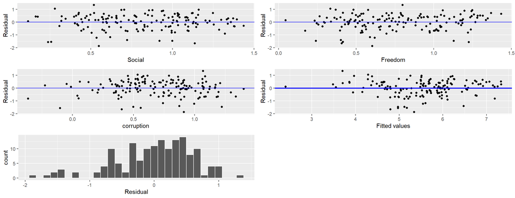

Scatterplots of the residuals by Social,Freedom,corruption,fitted value and the histogram of residuals.

The assumptions of the residuals having mean zero and constant variability across all values of the explanatory variable appear to be valid in this case. According to the three different explanatory variables scatter plots, it can be concluded that the residuals are uniformly distributed above and below the zero line, so the mean is 0. The residuals are randomly distributed around the zero line, and the distribution of the residuals is constant across all fitted values, so there is no obvious pattern or change in the variant. And also the histogram supports the assumption of normal distribution error.

After hypothesis testing, we will analyze the confidence interval and set the confidence level to 95%.

```
                2.5 %     97.5 %
(Intercept) -1.027760  1.1835605
Social       4.641318  6.6098138
Freedom      1.160482  3.2937585
corruption  -1.828636 -0.6222416
```